# High-Risk HPV and Anal Cancer amongst IBD Patients

# Increased Prevalence of High-Risk HPV+ DNA of Rectal cells in IBD Patients

Prior studies have established an increased rate of anal cancer in patients with IBD. Per *Albuquerque et al.*, the incidence of anal cancer per 100k person-years is as follows: 2 in the general population. 7.7 in Crohn’s, and 10.2 in Ulcerative Colitis. Notably, if a Crohn’s patient had prior perianal disease, it was 19.6 per 100k person-years, or *10 times* the incidence. (Albuquerque et al. 2023)

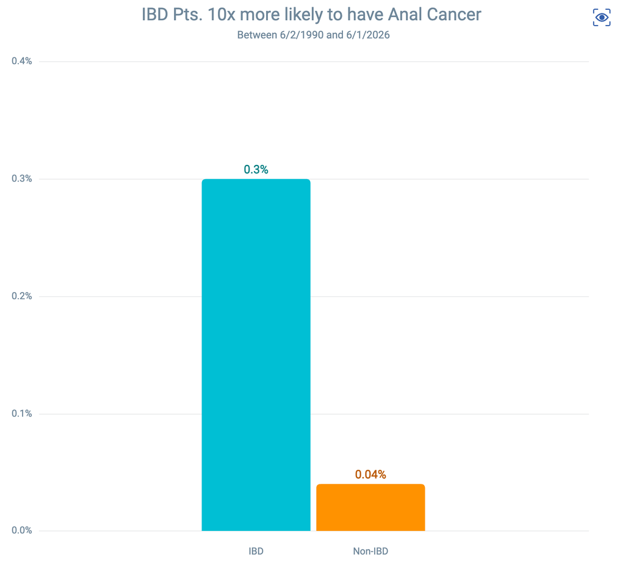

Figure 1. Anal cancer defined by ICD code: HGSIL of anus (R85.613), anal intraepithelial  
neoplasia III (D01.3), Dysplasia of Anus (K62.82)

## A Doubling and Tripling of High-Risk HPV+ DNA in Anal cells in IBD

When separating by Crohn’s vs Ulcerative Colitis, there is an increased prevalence amongst Ulcerative Colitis.

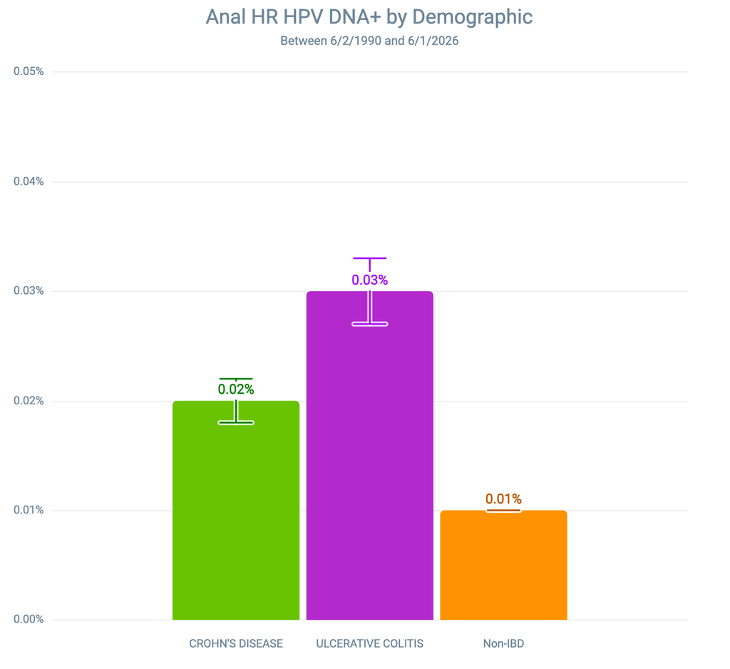

Figure 3. High-Risk HPV+ DNA from anal cells occur at 2x in Crohn’s, and 3x in UC  
compared to the general population

## Perianal Disease in Crohn’s

This relative increase in UC is true in most sectors we analysed, the one exception being prior perianal disease - in that case, Crohn’s patients had the higher prevalence. This is consistent with *Albuquerque et al.*’s finding of high prevalence of anal cancer with Crohn’s patients with perianal disease.

Of note, It is unclear what role surveillance of the IBD population may have affected discovery. For example, patients with perianal disease may be more likely to be evaluated.

However, if there is a high ratio of perianal disease patients that develop anal cancer, surveillance alone may not explain the higher rates. In a previous surgical study of a group of 33 IBD patients by *Slessler et al.* found that 85% of Crohn’s patients with anal cancer previously had perianal disease. However, this was specifically a group of anal SCC patients, so it is difficult to assess how this group relates to the larger body of Crohn’s patients with perianal disease. (Slesser et al. 2013)

### Severity and Aggression of Anal Cancers in Crohn’s patients

*Slessler et al.* noted earlier age of presentation and poorer outcomes with the select group of anal SCC patients in their retrospective analysis. I think this is something we should dig deeper into - how do we measure severity - is a combination of staging of the malignancy and age enough of a metric?

## Perianal Disease and Anal Cancer

About 22% of Crohn’s patients with Anal Cancer had Perianal disease in the 5 years prior to diagnosis (559/2535). For UC, about 15% had prior perianal disease (474/3227). Chi-Square of 52.3, p<0.001. In the general population, there was a minimal percentage of patients that had perianal disease, however we hypothesize that such rate is not comparable as screening for such a condition is not routine and likely skews the percentage.

```
                   Prior perianal disease No prior perianal disease
Crohn disease                         559                      1976
Ulcerative colitis                    474                      2753
```

```
    Pearson's Chi-squared test

data:  perianal_anal_cancer_counts
X-squared = 52.307, df = 1, p-value = 4.748e-13
```

Pearson chi-square testing showed that prior perianal disease was significantly more common among Crohn’s patients with anal cancer than UC patients with anal cancer, X<sup>2</sup>(1) = 52.3, p < 0.001.

# Proposed Mechanisms, Discussion, Areas to Further Study

## Anal Sparing in Ulcerative Colitis

While rectal involvement is Ulcerative Colitis is nearly universal, the anal canal is generally spared. This would seem to contradict the data that shows a higher rate of anal cancer in UC patients. High-Risk HPV rates are also increased at this location, which may factor into the higher rates of anal cancer.

## Azathioprine Use Does Not Seem to Correlate

Azathioprine is known to have some correlation to HPV and Cervical cancer, so we analysed if incidence of anal cancer in HRHPV+ patients may be increased in patients using Azathioprine. There was a higher use rate of Azathioprine for patients who had Crohn’s (7.48%) than Ulcerative Colitis (5.21%). However, when looking at patients with both IBD and anal HRHPV+ DHA, less than 10% of Anal HRHPV+ Crohn’s patients were on Azathioprine, and less than 5% of Anal HRHPV+ UC patients were on Azathioprine.

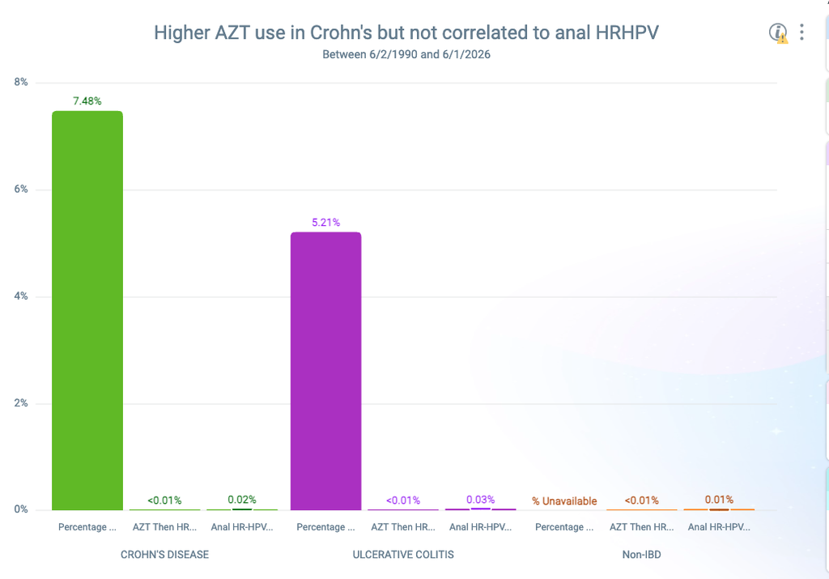

## Future Proposals

With the higher rates of High-Risk HPV positive DNA in IBD patients, regular screening for these patients may have an outsized effect on rates of anal cancer.

Further study that may be of benefit, to stratify the population:

Progression to Anal Cancer

Immunosuppressive medication use - analysis of patients’ history of Azathioprine, which is known to have a connection to cervical cancer

Rates of Anal HPV or Anal cancer in CVID patients

## References

Albuquerque, Andreia, Carmelina Cappello, Oliver Stirrup, and Christian P Selinger. 2023. “Anal High-risk Human Papillomavirus Infection, Squamous Intraepithelial Lesions, and Anal Cancer in Patients with Inflammatory Bowel Disease: A Systematic Review and Meta-analysis.” *Journal of Crohn’s and Colitis* 17 (8): 1228–34. https://doi.org/10.1093/ecco-jcc/jjad045.

Slesser, A. A. P., A. Bhangu, M. Bower, R. Goldin, and P. P. Tekkis. 2013. “A Systematic Review of Anal Squamous Cell Carcinoma in Inflammatory Bowel Disease.” *Surgical Oncology* 22 (4): 230–37. https://doi.org/10.1016/j.suronc.2013.08.002.